# Weight Lifting Error Classification

Ben Daniel

October 24, 2015

# Summary

As stated in the assingment, body movement montiors have now become very cheap, and they allow us to collect vast amounts of data about our body’s movements. The data set given in this assignment from (Human Activity Recognition , http://groupware.les.inf.puc-rio.br/har ) tracks the lifting of a dumbell. Dumbell lifts that are done incorrectly are classified and features about the lift are documented.

# Data

# Selecting Data

In the code below, data is read into a dataframe. A subset of columns for uncalcualted variables are selected from the overall dataset.

```r
library(caret)
library(rattle)
library(dplyr)
library(rpart)
library(randomForest)
rawmotionDat <- read.csv("data/pml-training.csv")

#get rid of unncessary variables, only pick the variables with raw,yaw,or pitch
#throw out anyting with lots of NAs

motionDat<- rawmotionDat %>%
        select(one_of(c("roll_belt","pitch_belt","yaw_belt",
                        "total_accel_belt","gyros_belt_x","gyros_belt_y","gyros_belt_z",
                        "accel_belt_x","accel_belt_y","accel_belt_z","magnet_belt_x",
                        "magnet_belt_y","magnet_belt_z","roll_arm","pitch_arm","yaw_arm",
                        "total_accel_arm","gyros_arm_x","gyros_arm_y","gyros_arm_z",
                        "accel_arm_x","accel_arm_y","accel_arm_z","magnet_arm_x",
                        "magnet_arm_y","magnet_arm_z","roll_dumbbell","pitch_dumbbell",
                        "yaw_dumbbell","total_accel_dumbbell","gyros_dumbbell_x",
                        "gyros_dumbbell_y","gyros_dumbbell_z","accel_dumbbell_x",
                        "accel_dumbbell_y","accel_dumbbell_z","magnet_dumbbell_x",
                        "magnet_dumbbell_y","magnet_dumbbell_z","roll_forearm","pitch_forearm",
                        "yaw_forearm","gyros_forearm_x","gyros_forearm_y","gyros_forearm_z",
                        "accel_forearm_x","accel_forearm_y","accel_forearm_z",
                        "magnet_forearm_x","magnet_forearm_y","magnet_forearm_z","classe")))
```

The training data set was quite large (19K records). I subsetted it by a 60-20-20 ratio into training, validation, and test sets. Cross validation was done via a correlation matrix.

```r
#create a validation data set from the training set
#60% training, 20% validation, 20% test
#subsample with caret
#
# Cross-validation
# Approach:
#
# Use the training set
#         Split it into training/test sets
#         Build a model on the training setr
#         Evaluate on the test set
#         Repeat and average the estimated errors
#
# Used for:
#
#         Picking variables to include in a model
#         Picking the type of prediction function to use
#         Picking the parameters in the prediction function
#         Comparing different predictors

       inTrain <- createDataPartition(y=motionDat$classe,p=.6,list=FALSE)
       training <- motionDat[inTrain,]
       nottrain <- motionDat[-inTrain,]

       M<-abs(cor(training [,1:51]))
       diag(M)<-0
       newM<-which(M > .8, arr.ind=T) #get the variables whose correlation is > .8
       important_vars<-as.data.frame(rownames(newM))%>%distinct()
       important_vars_n<-c(as.character(important_vars[,1]),"classe") #append the classifier (output) var
       #the training set was resubsetted by selecteing imprant columns
       training<-select(training,one_of(important_vars_n))
       nottrain <- select(nottrain,one_of(important_vars_n))

#in the above example, we held out 60% for the training, thus notrain is 40%, since the
#recommendation for sizes of validation and test set data is 20% of the original, I will
#split this part in half

       v_and_t<- createDataPartition(y=nottrain$classe,p=.5,list=FALSE)
       validation <- nottrain[v_and_t,]
       pretest <- nottrain[-v_and_t,]
```

# Model Construction

I compared two model types: the first was rpart, and the second was random forest. The next code sample demonstrates building both types of models. Note that the prediction is done with the validation dataset; data is training for each respective modFit variable, and it is validation for each pred variable.

```r
       #since this is a classification problem, I am going to choose the rpart model and start a tree.
#model, at first.  I may try a model with random forests or boosting as well.
modFitTree <- train(classe ~ ., method="rpart",data=training)
predTree <- predict(modFitTree,newdata=validation)

#let's try random forrest model
modFitRF <- randomForest(classe ~ ., method="rf",data=training,prox=TRUE,importance=TRUE)
#much better accuracy, but let's try with validation
predRF <- predict(modFitRF,newdata=validation)
```

# Results

Using the confusion matrix, we are able to observe the output of each type of model

The RPart Model

```r
cfTree<-confusionMatrix(validation$classe,predict(modFitTree,newdata=validation))
print(cfTree)
```

```
## Confusion Matrix and Statistics
##
##           Reference
## Prediction   A   B   C   D   E
##          A 855   8   0 251   2
##          B 212 235   0 312   0
##          C 313  22   0 349   0
##          D 141  13   0 489   0
##          E  73  91   0 248 309
##
## Overall Statistics
##
##                Accuracy : 0.4813
##                  95% CI : (0.4655, 0.497)
##     No Information Rate : 0.4203
##     P-Value [Acc > NIR] : 8.333e-15
##
##                   Kappa : 0.3373
##  Mcnemar's Test P-Value : NA
##
## Statistics by Class:
##
##                      Class: A Class: B Class: C Class: D Class: E
## Sensitivity            0.5364  0.63686       NA   0.2965  0.99357
## Specificity            0.8879  0.85256   0.8256   0.9323  0.88594
## Pos Pred Value         0.7661  0.30962       NA   0.7605  0.42857
## Neg Pred Value         0.7367  0.95765       NA   0.6463  0.99938
## Prevalence             0.4063  0.09406   0.0000   0.4203  0.07928
## Detection Rate         0.2179  0.05990   0.0000   0.1246  0.07877
## Detection Prevalence   0.2845  0.19347   0.1744   0.1639  0.18379
## Balanced Accuracy      0.7122  0.74471       NA   0.6144  0.93975
```

As shown in the figure above, the cfTree only provides about 50% accuracy.

The Random Forest Model

```r
cfRM<-confusionMatrix(validation$classe,predRF)
print(cfRM)
```

```
## Confusion Matrix and Statistics
##
##           Reference
## Prediction    A    B    C    D    E
##          A 1097    3    4   12    0
##          B    6  735   11    7    0
##          C    5    6  666    7    0
##          D    2    0   16  625    0
##          E    1    3    3    2  712
##
## Overall Statistics
##
##                Accuracy : 0.9776
##                  95% CI : (0.9724, 0.982)
##     No Information Rate : 0.2832
##     P-Value [Acc > NIR] : < 2.2e-16
##
##                   Kappa : 0.9716
##  Mcnemar's Test P-Value : 0.001137
##
## Statistics by Class:
##
##                      Class: A Class: B Class: C Class: D Class: E
## Sensitivity            0.9874   0.9839   0.9514   0.9571   1.0000
## Specificity            0.9932   0.9924   0.9944   0.9945   0.9972
## Pos Pred Value         0.9830   0.9684   0.9737   0.9720   0.9875
## Neg Pred Value         0.9950   0.9962   0.9895   0.9915   1.0000
## Prevalence             0.2832   0.1904   0.1784   0.1665   0.1815
## Detection Rate         0.2796   0.1874   0.1698   0.1593   0.1815
## Detection Prevalence   0.2845   0.1935   0.1744   0.1639   0.1838
## Balanced Accuracy      0.9903   0.9882   0.9729   0.9758   0.9986
```

The random forest model is much more accurate because of its resampling methods.

The following figure compares the two confusion matrices. (sample code adapted from http://oobaloo.co.uk/visualising-classifier-results-with-ggplot2)

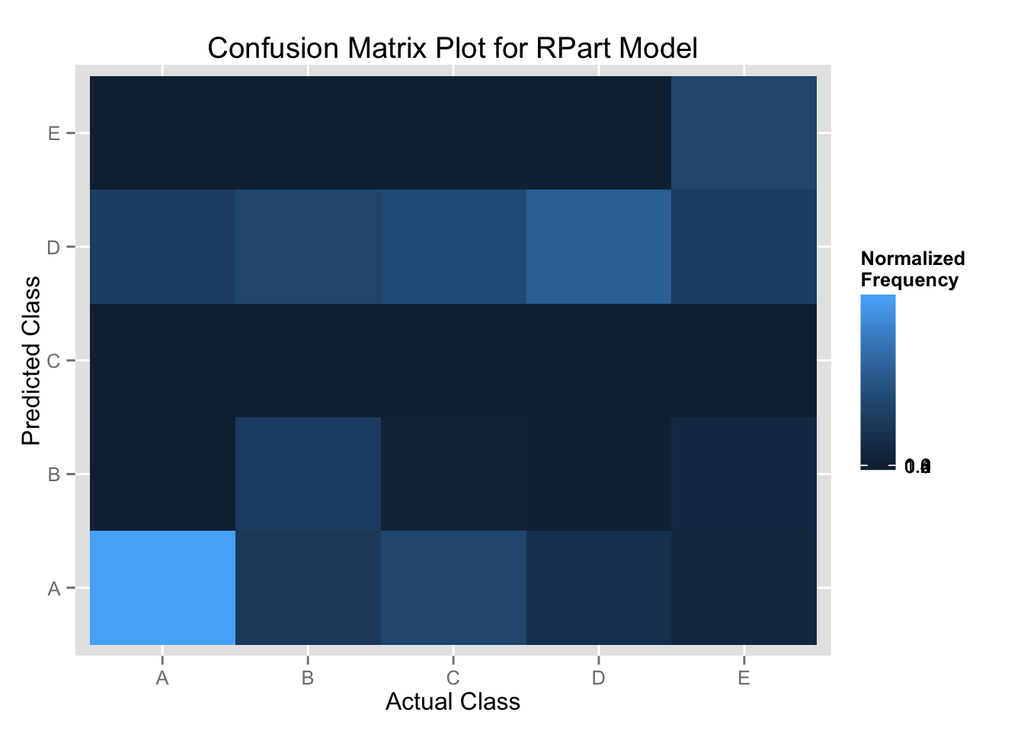

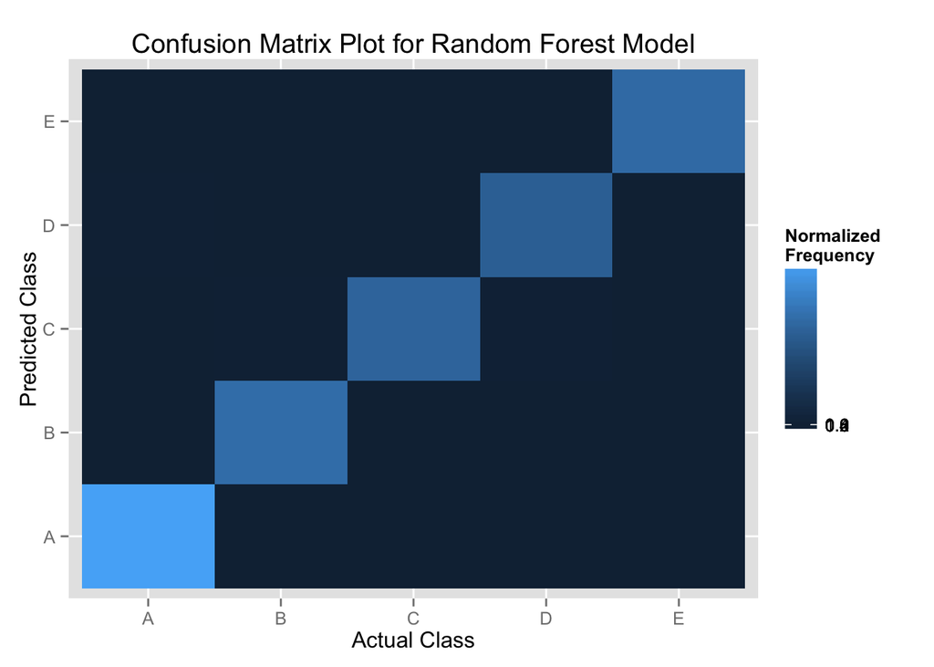

Notice that the diagnonal (a correct prediction) is much stronger in the second graph compared to the first graph.